# Lab 07: Airline Tweets Sentiment Analysis

Author

Afnan Dzaharudin

Published

April 1, 2024

# Introduction

If your Twitter feed isn’t busy being filled with hostile discourse, you’ll see the occasional complaint about some company, and usually, you’ll see that mentioned company’s twitter account’s response in the comments!

The same applies to airline companies. Twitter users may say something good or bad (usually bad) about their flight experience, and airline companies are likely interested in being able to differentiate between positive and negative tweets, in order to send them an automated response, and also to (hopefully) improve their service given these complaints.

And so, in this report, we aim to create a model that can classify tweets directed to US airlines as either negative, neutral, or positive tweets.

# Methods

```python
# imports
import pandas as pd
import numpy as np
import matplotlib.pyplot as plt
import seaborn as sns
sns.set_theme(style="ticks", palette="deep")

# sklearn: viz
from sklearn.metrics import ConfusionMatrixDisplay
from sklearn.metrics import confusion_matrix

# sklearn: utilities
from sklearn.model_selection import train_test_split
from sklearn.feature_extraction.text import CountVectorizer
from sklearn.base import BaseEstimator, TransformerMixin

# sklearn: transformers
from sklearn.pipeline import Pipeline
from sklearn.impute import SimpleImputer
from sklearn.preprocessing import PolynomialFeatures, StandardScaler, FunctionTransformer
from sklearn.compose import ColumnTransformer

# sklearn: metrics
from sklearn.metrics import fbeta_score, make_scorer, recall_score, precision_score

# sklearn:prediction models
from sklearn.model_selection import GridSearchCV
from sklearn.naive_bayes import MultinomialNB

# show me ALL the plots!
from IPython.display import display

from joblib import dump
```

To create our classifier, we convert our tweet data into “bags of words”, using a `CountVectorizer` from scikit-learn to return the frequency of found words for each tweet. We then use multinomial Naive Bayes, or `MultinomialNB`, to classify these count-vectorized tweets, using `GridSearchCV` to find our best parameters.

## Data

```python
# load data
tweets = pd.read_csv("https://cs307.org/lab-07/data/tweets.csv")

# train-test split
tweets_train, tweets_test = train_test_split(
    tweets,
    test_size=0.25,
    random_state=42,
)

# create X and y for train data
X_train = tweets_train["text"]
y_train = tweets_train["sentiment"]

# create X and y for test data
X_test = tweets_test["text"]
y_test = tweets_test["sentiment"]

tweets
```

Table 1: First and Last Five Rows of `tweets`

|  | sentiment | airline | text |
| --- | --- | --- | --- |
| 0 | negative | United | @united at its worse. Can't figure how to pack... |
| 1 | negative | Delta | @JetBlue I did not report the updated info - d... |
| 2 | negative | Delta | @JetBlue I'll give u a chance but I don't thin... |
| 3 | negative | United | @united Yo yo yo stuck on the tarmac for over ... |
| 4 | negative | US Airways | @USAirways yes, I was rebooked the next day (W... |
| ... | ... | ... | ... |
| 10975 | positive | Southwest | @SouthwestAir replacing @vitaminwater with bee... |
| 10976 | negative | American | @AmericanAir at LAX and your service reps just... |
| 10977 | negative | Southwest | @SouthwestAir Been on hold for over an hour - ... |
| 10978 | negative | United | @united we would...how do I contact you to dis... |
| 10979 | neutral | Delta | @JetBlue that's ok! It just sure seemed like i... |

10980 rows × 3 columns

We have 10,980 rows of data, and only three columns:

1. `sentiment` is our target. It contains one of three values: ‘negative’, ‘neutral’, or ‘positive’.
2. `airline` indicates the US airline the tweet was directed to, but we will only use it in summary statistics rather than for prediction.
3. `text` is the full text of the tweet directed to an airline.

The data was scraped from Twitter on February 2015 and posted to [Kaggle, here](https://www.kaggle.com/datasets/crowdflower/twitter-airline-sentiment). The tweets were manually classified by human contributors, either as positive, negative, or neutral. The tweets are directed to one of six airlines: United, US Airways, American Airlines, Southwest Airlines, Delta Airlines, or Virgin America.

### Summary Statistics

```python
airline_count = tweets_train['airline'].value_counts()
airline_prop = tweets_train['airline'].value_counts(normalize=True)

airlines = pd.DataFrame({
    'count': airline_count,
    'proportion': airline_prop
})

airlines
```

Table 2: Counts and Proportions of US Airlines Mentioned in Tweets

| airline | count | proportion |
| --- | --- | --- |
| United | 2166 | 0.263024 |
| US Airways | 1664 | 0.202064 |
| American | 1551 | 0.188342 |
| Southwest | 1347 | 0.163570 |
| Delta | 1239 | 0.150455 |
| Virgin America | 268 | 0.032544 |

```python
sentiment_count = tweets_train['sentiment'].value_counts()
sentiment_prop = tweets_train['sentiment'].value_counts(normalize=True)

sentiments = pd.DataFrame({
    'count': sentiment_count,
    'proportion': sentiment_prop
})

sentiments
```

Table 3: Counts and Proportions of Tweet Sentiments

| sentiment | count | proportion |
| --- | --- | --- |
| negative | 5118 | 0.621494 |
| neutral | 1810 | 0.219794 |
| positive | 1307 | 0.158713 |

We can see that most of our tweets are directed to United Airlines, and the least are directed to Virgin America.

Additionally, a large majority of our tweets have a negative sentiment, while positive tweets have the lowest count (expected of Twitter).

### Visualizations

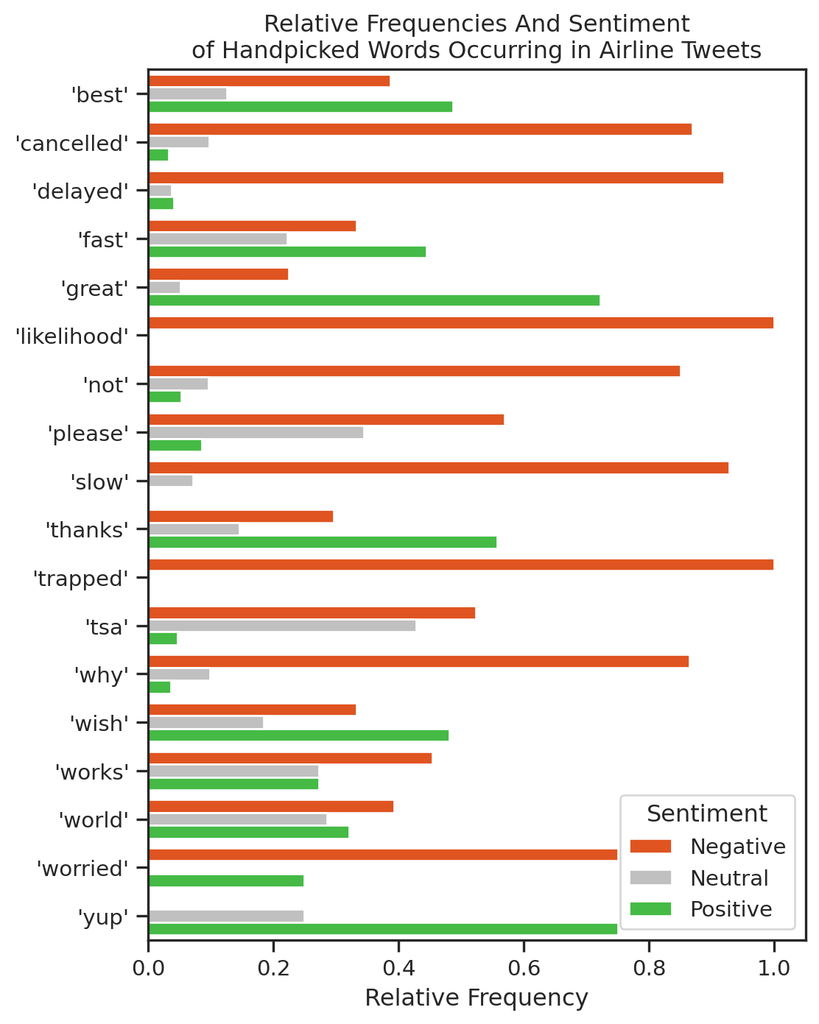

```python
vectorizer = CountVectorizer()
mat_counts = vectorizer.fit_transform(X_train)
mat_counts_dense = mat_counts.todense()

cols = vectorizer.get_feature_names_out()

df_bag = pd.DataFrame(mat_counts_dense, columns=cols)
df_bag['sentiment'] = y_train.reset_index(drop=True)

wanted_cols = ['yup', 'worried', 'world', 'works',
    'cancelled', 'please', 'thanks', 'wish',
    'not', 'why', 'trapped', 'great', 'fast',
    'slow', 'delayed', 'best', 'likelihood',
    'tsa']
wanted_cols.sort()

colors = ['orangered', 'silver', 'limegreen']

df_sums = df_bag.groupby('sentiment').agg('sum')
df_sums = df_sums.apply(lambda x: x / x.sum())
df_melt = df_sums[wanted_cols].reset_index().melt(id_vars=['sentiment'])
df_melt['variable'] = df_melt['variable'].apply(lambda s: "'{}'".format(s))
df_melt['sentiment'] = df_melt['sentiment'].apply(lambda s: s.capitalize())

plt.figure(figsize=(6, 8))
sns.barplot(df_melt, y='variable', x='value', hue='sentiment',
    palette=colors)

plt.title("Relative Frequencies And Sentiment\nof Handpicked Words Occurring in Airline Tweets")
plt.xlabel("Relative Frequency")
plt.ylabel(None)
plt.legend(title="Sentiment")
plt.show()
```

There are many *many* words in a tweet, so we only picked a few that would be fun to look at. The plot above shows, for each word, the proportion of tweets that are negative, neutral, or positive, given that tweet contains that word.

## Models

```python
# pipelines
pipe_nb = Pipeline([
    ("vectorizer", CountVectorizer()),
    ("classifier", MultinomialNB())
])

params_nb = {
    "vectorizer__max_features": np.arange(1000, 15000, 500),
    "vectorizer__min_df": [2, 3],
    "vectorizer__ngram_range": [(1, 1), (1, 2), (2, 2)],
}
```

```python
grid_nb = GridSearchCV(pipe_nb, params_nb, cv=5, scoring="accuracy")
_ = grid_nb.fit(X_train, y_train)

grid_nb.best_score_, grid_nb.best_params_
```

```
(0.7863995142683667,
 {'vectorizer__max_features': 11000,
  'vectorizer__min_df': 2,
  'vectorizer__ngram_range': (1, 2)})
```

Here we try our `MultinomialNB` classifier, where, after some experimentation, we found that our results were impacted more by tuning the `CountVectorizer` than the Naive Bayes model itself.

Our best model was found to use a `CountVectorizer` that limits the number of features to 11,000, ignores words with a frequency lower than 2, and uses an n-gram range of (1,2), meaning we count both one-word and two-word phrases. Our guess as to why this is helpful is that the model can account for negations of words like “not great” or “isn’t fast”.

## Results

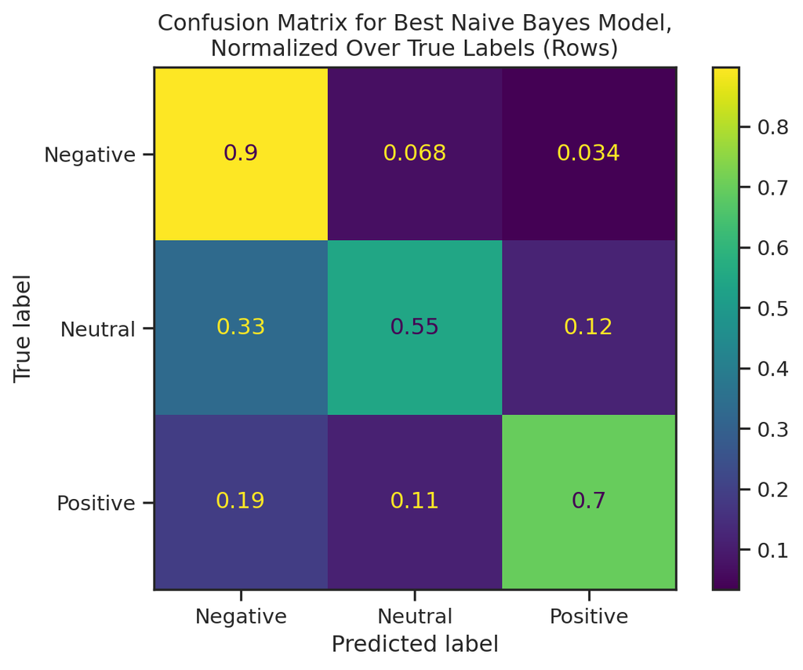

```python
# A confusion matrix!
phat_test = grid_nb.predict(X_test)
cm = confusion_matrix(y_test, phat_test, normalize='true')
labels = [s.capitalize() for s in grid_nb.classes_]
disp = ConfusionMatrixDisplay(confusion_matrix=cm, display_labels=labels)

disp.plot()
plt.title("Confusion Matrix for Best Naive Bayes Model,\nNormalized Over True Labels (Rows)")
plt.show()
```

```python
# report model metrics
grid_nb.score(X_test, y_test)
```

```
0.7927140255009107
```

We obtained an overall test accuracy of 0.7927, or roughly 79.3%, which meets the imposed requirements!

The confusion matrix gives us a more nuanced insight on the test predictions:

## Discussion

With an overall accuracy of 79%, and true positive rates of 90%, 55%, and 70% for negative, neutral, and positive tweets respectively, our Naive Bayes has strengths and weaknesses we should address in consideration of its use.

When a given tweet has negative sentiment, our model would be *very* likely to correctly classify it as such, with a rate of 90%. This is good, because negative sentiment tends to be the most important type to respond to appropriately. Perhaps due to the sheer quantity of negative tweets (Table 3), the classifier also tends to mispredict neutral and positive tweets as negative.

Neutral tweets seem to have the most uncertainty, as Naive Bayes only correctly classifies it 55% of the time. We argue this is not consequential though; responding positively to a neutral tweet is just fine, and responding to a neutral with condolences as if it were negative is at worst annoying, and at best, funny.

Positive tweets have a decent sensitivity of 70%. Similar to neutral tweets, though, we don’t believe it’s a big issue of positive tweets *were* responded to as if they were negative, as it again, mostly just a funny slip-up that is extremely unlikely hamper a customer’s good experience.

Overall, we think our Naive Bayes model is highly appropriate for real-world use, as it excels where it matters most: correctly identifying negative tweets, which are most important to correctly identify and appropriately respond to. Some may argue that missing 1 out of 10 negative tweets is still too frequent, though, in which case, greater tuning is needed.

### Conclusion

It is possible to use a multinomial Naive Bayes classifier to classify the sentiment of a tweet, with an accuracy of roughly 79%.